## Intro

The goal of this project is to display the EDA process for building prediction model of text data from SwiftKey.  
It is related with natural language processing(NLP).  
Let’s start our first text mining project.

## Contents

1. Download and load the data sets
2. Summary statistics about the data sets
3. Plot and Report
4. Plan

## 1. Download and load the data sets

Let’s download the ‘Coursera-SwiftKey.zip’ file and unzip.  
And load the files.

```r
download.file("https://d396qusza40orc.cloudfront.net/dsscapstone/dataset/Coursera-SwiftKey.zip", destfile = "capstone.zip")
unzip("capstone.zip")
setwd("final/en_US")

en_twit <- readLines(connect1 <- file("en_US.twitter.txt"), encoding = "UTF-8", skipNul = TRUE)
close(connect1)

en_blog <- readLines(connect2 <- file("en_US.blogs.txt"), encoding = "UTF-8", skipNul = TRUE)
close(connect2)

en_news <- readLines(connect3 <- file("en_US.news.txt"), encoding = "UTF-8", skipNul = TRUE)
close(connect3)
```

## 2. Summary statistics about the data sets

Before start EDA, We need two packages as below :

```r
library(tidyverse)
library(tidytext)
```

We should change the data format as tibble and let’s combine the data sets.

```r
en_twit <- as_tibble(en_twit)
en_blog <- as_tibble(en_blog)
en_news <- as_tibble(en_news)

dcmt <- bind_rows("twitter" = en_twit, "blogs" = en_blog, "news" = en_news, .id = "category")
names(dcmt) <- c("category", "text")
```

Let’s check the data set

```r
glimpse(dcmt)
```

```
## Rows: 3,336,695
## Columns: 2
## $ category <chr> "twitter", "twitter", "twitter", "twitter", "twitter", "tw...
## $ text     <chr> "How are you? Btw thanks for the RT. You gonna be in DC an...
```

```r
str(dcmt)
```

```
## tibble [3,336,695 x 2] (S3: tbl_df/tbl/data.frame)
##  $ category: chr [1:3336695] "twitter" "twitter" "twitter" "twitter" ...
##  $ text    : chr [1:3336695] "How are you? Btw thanks for the RT. You gonna be in DC anytime soon? Love to see you. Been way, way too long." "When you meet someone special... you'll know. Your heart will beat more rapidly and you'll smile for no reason." "they've decided its more fun if I don't."…
```

```r
dcmt %>% group_by(category) %>%
  summarise(count = n(), max_length = max(nchar(text)))
```

```
## # A tibble: 3 x 3
##   category   count max_length
##   <chr>      <int>      <int>
## 1 blogs     899288      40833
## 2 news       77259       5760
## 3 twitter  2360148        140
```

There are over 2 million lines in the twitter category and there is the longest line seen in the blogs category.

# Uni-gram : Build tidy word set

Let’s make sample date set.

```r
set.seed(1222)
dcmt_samp <- dcmt %>% group_by(category) %>%
  sample_frac(size = .1, replace = FALSE)
```

Count words

```r
dcmt_samp %>%
  group_by(category) %>%
  unnest_tokens(word, text) %>%
  count(category, sort = TRUE)
```

```
## # A tibble: 3 x 2
## # Groups:   category [3]
##   category       n
##   <chr>      <int>
## 1 blogs    3758792
## 2 twitter  3015752
## 3 news      265250
```

# Count word in each category

```r
dcmt_samp_wd <- dcmt_samp %>%
  group_by(category) %>%
  unnest_tokens(word, text) %>%
  anti_join(stop_words) %>%
  count(category, word, sort = TRUE) %>%
  mutate(word2 = fct_reorder(word, n))
dcmt_samp_wd %>% top_n(10)
```

```
## # A tibble: 30 x 4
## # Groups:   category [3]
##    category word       n word2
##    <chr>    <chr>  <int> <fct>
##  1 blogs    time    9103 time
##  2 blogs    people  5899 people
##  3 blogs    day     5260 day
##  4 blogs    love    4426 love
##  5 blogs    life    4263 life
##  6 blogs    it’s    3970 it’s
##  7 blogs    1       2959 1
##  8 blogs    2       2955 2
##  9 blogs    i’m     2884 i’m
## 10 blogs    don’t   2867 don’t
## # ... with 20 more rows
```

# Bi-gram

Count bigrams

```r
dcmt_samp %>%
  group_by(category) %>%
  unnest_tokens(bigram, text, token = "ngrams", n = 2) %>%
  count(category)
```

```
## # A tibble: 3 x 2
## # Groups:   category [3]
##   category       n
##   <chr>      <int>
## 1 blogs    3758791
## 2 news      265249
## 3 twitter  3015751
```

Count bigrams in each category

```r
dcmt_samp_bigm <- dcmt_samp %>%
  group_by(category) %>%
  unnest_tokens(bigram, text, token = "ngrams", n = 2)

dcmt_samp_bigm_sp <- dcmt_samp_bigm %>%
  separate(bigram, into = c("word1", "word2"), remove = FALSE, sep = "\\s")

dcmt_samp_bigm_sp_cnt <- dcmt_samp_bigm_sp %>%
  filter(!word1 %in% stop_words$word & !word2 %in% stop_words$word) %>%
  count(bigram, sort = TRUE) %>%
  mutate(bigram2 = fct_reorder(bigram, n))

dcmt_samp_bigm_sp_cnt %>% top_n(10)
```

```
## # A tibble: 30 x 4
## # Groups:   category [3]
##    category bigram             n bigram2
##    <chr>    <chr>          <int> <fct>
##  1 blogs    1 2              379 1 2
##  2 twitter  rt rt            228 rt rt
##  3 blogs    ice cream        183 ice cream
##  4 twitter  lol rt           168 lol rt
##  5 blogs    weeks ago        165 weeks ago
##  6 twitter  awkward moment   156 awkward moment
##  7 blogs    social media     145 social media
##  8 blogs    1 4              136 1 4
##  9 blogs    olive oil        135 olive oil
## 10 blogs    jesus christ     130 jesus christ
## # ... with 20 more rows
```

# Tri-gram

Count triigrams

```r
dcmt_samp %>%
  group_by(category) %>%
  unnest_tokens(trgram, text, token = "ngrams", n = 3) %>%
  count(category)
```

```
## # A tibble: 3 x 2
## # Groups:   category [3]
##   category       n
##   <chr>      <int>
## 1 blogs    3758790
## 2 news      265248
## 3 twitter  3015750
```

Count triigrams in each category

```r
dcmt_samp_trgm <- dcmt_samp %>%
  group_by(category) %>%
  unnest_tokens(trgram, text, token = "ngrams", n = 3)

dcmt_samp_trgm_sp <- dcmt_samp_trgm %>%
  separate(trgram, into = c("word1", "word2", "word3"), remove = FALSE, sep = "\\s")

dcmt_samp_trgm_sp_cnt <- dcmt_samp_trgm_sp %>%
  filter(!word1 %in% stop_words$word &
         !word2 %in% stop_words$word &
         !word3 %in% stop_words$word) %>%
  count(trgram, sort = TRUE) %>%
  mutate(trgram2 = fct_reorder(trgram, n))
```

# plot of Uni-gram

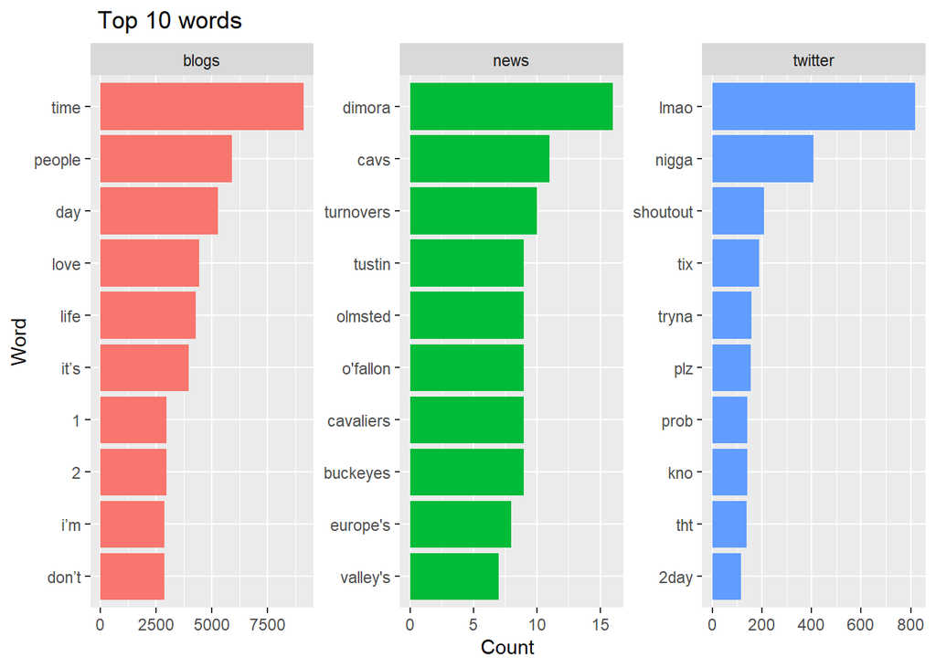

```r
dcmt_samp_wd %>%
  group_by(category) %>%
  top_n(10) %>%
  ggplot(aes(x = word2, y = n, fill = category))+
  geom_col(show.legend = FALSE)+
  coord_flip()+
  labs(title = " Top 10 words", x = "Word", y = "Count")+
  facet_wrap(~category, scales = "free")
```

There are ‘time’, ‘people’, ‘day’, ‘love’, ‘life’ and etc in blogs.  
I guess those are related with personal private life story.

There are many abbreviation and slang in twitter.

# plot of Bi-gram

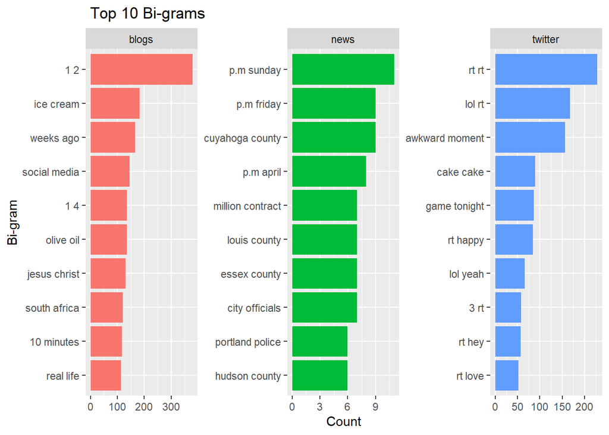

```r
dcmt_samp_bigm_sp_cnt %>%
  group_by(category) %>%
  top_n(10) %>%
  ggplot(aes(x = bigram2, y = n, fill = category))+
  geom_col(show.legend = FALSE)+
  coord_flip()+
  labs(title = " Top 10 Bi-grams", x = "Bi-gram", y = "Count")+
  facet_wrap(~category, scales = "free")
```

# plot of Tri-gram

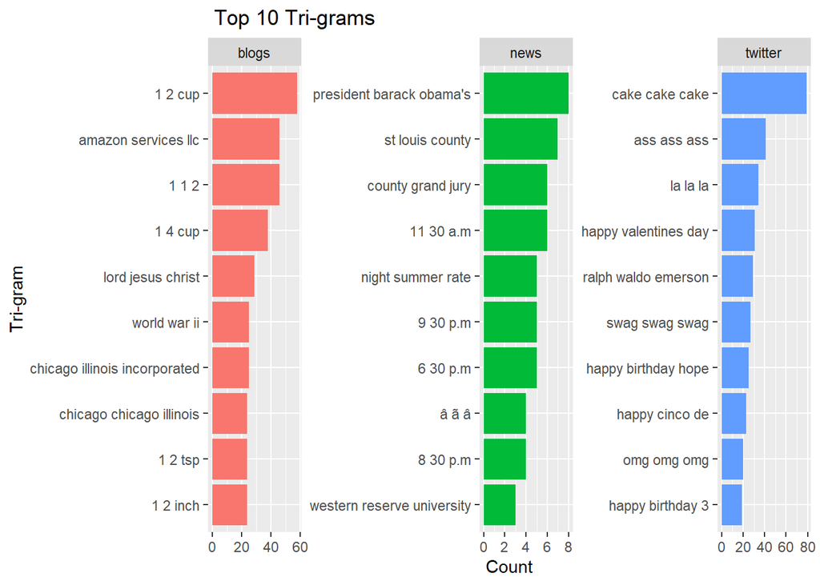

```r
dcmt_samp_trgm_sp_cnt %>%
  group_by(category) %>%
  top_n(10) %>%
  ggplot(aes(x = trgram2, y = n, fill = category))+
  geom_col(show.legend = FALSE)+
  coord_flip()+
  labs(title = " Top 10 Tri-grams", x = "Tri-gram", y = "Count")+
  facet_wrap(~category, scales = "free")
```

There are many times in news.  
And there are tri-grams related with special day.

## 4. Plan

Next time, I will creating a prediction algorithm and Shiny app.  
Thank you for your kind review.